# Прогнозирование урожайности сельскохозяйственных культур

**Информация, содержащаяся в датасете:**

1. Температура, °C ('Temperature').
2. Количество осадков, мм('Rainfall').
3. Кислотность почвы ('Soil_pH').
4. Количество внесенных удобрений, кг/га ('Fertilizer').
5. Содержание легкогидролизируемого азота в почве, мг/кг ('Nitrogen(N)').
6. Содержание подвижного фосфора в почве ('Phosphorus(P)').
7. Содержание обменного калия в почве ('Potassium(K)').
8. Тип культуры ('Crop_Type'): пшеница, рис и кукуруза.
9. Урожайность, тонн/га ('Yield') целевая переменная для прогнозирования.

**Количество строк:** 2694.

```python
import numpy as np
import pandas as pd
import matplotlib.pyplot as plt
import seaborn as sns
import statsmodels.api as sm

from scipy.stats import f_oneway, ks_2samp, shapiro, levene, kruskal
from sklearn.preprocessing import StandardScaler
from statsmodels.stats.diagnostic import het_breuschpagan
from statsmodels.stats.outliers_influence import variance_inflation_factor
```

```python
!gdown -- 1gxs1GDoih_BxbubsWYGz6Lc_3Z7qP32B
```

```
Downloading...
From: https://drive.google.com/uc?id=1gxs1GDoih_BxbubsWYGz6Lc_3Z7qP32B
To: /content/crop_yield_prediction.csv
100% 142k/142k [00:00<00:00, 91.3MB/s]
```

```python
df = pd.read_csv('crop_yield_prediction.csv')
df.head()
```

|  | Temperature | Rainfall | Soil_pH | Fertilizer | Nitrogen(N) | Phosphorus(P) | Potassium(K) | Crop_Type | Yield |
| --- | --- | --- | --- | --- | --- | --- | --- | --- | --- |
| 0 | 29.74 | 268.03 | 6.76 | 61.63 | 73.74 | 37.64 | 35.11 | Wheat | 14.04 |
| 1 | 37.41 | 183.95 | 7.60 | 55.17 | 64.31 | 39.71 | 33.95 | Wheat | 14.70 |
| 2 | 33.55 | 204.98 | 5.50 | 107.10 | 65.50 | 38.38 | 33.61 | Wheat | 10.85 |
| 3 | 32.04 | 161.19 | 6.75 | 103.75 | 71.47 | 35.54 | 32.93 | Rice | 10.09 |
| 4 | 26.71 | 220.45 | 7.62 | 177.87 | 68.52 | 38.79 | 38.07 | Wheat | 14.70 |

```python
print(f'Описательные статистики для числовых переменных: \n{df.describe()}')
print(f"\nЧастота для различных культур: {df['Crop_Type'].value_counts()}")
```

```
Описательные статистики для числовых переменных:
       Temperature     Rainfall      Soil_pH   Fertilizer  Nitrogen(N)  \
count  2694.000000  2694.000000  2694.000000  2694.000000  2694.000000
mean     30.930022   186.053749     6.523842    94.678478    68.433512
std       3.933776    41.789281     0.834360    37.986398     4.802513
min      21.360000   100.370000     5.100000    49.600000    55.300000
25%      28.082500   154.522500     5.800000    64.172500    65.140000
50%      31.100000   180.460000     6.510000    83.845000    68.470000
75%      33.760000   215.277500     7.240000   115.937500    71.687500
max      40.080000   296.480000     8.000000   206.640000    81.800000

       Phosphorus(P)  Potassium(K)        Yield
count    2694.000000   2694.000000  2694.000000
mean       39.049922     33.701901    11.799569
std         2.335163      2.215246     2.252476
min        33.910000     29.050000     6.270000
25%        37.340000     32.060000    10.140000
50%        38.900000     33.460000    11.950000
75%        40.750000     35.210000    13.870000
max        45.020000     39.400000    14.700000

Частота для различных культур: Crop_Type
Corn     906
Rice     895
Wheat    893
Name: count, dtype: int64
```

# 1. Теория вероятностей и мат. статистика

## 1.1 Анализ датасета на предмет распределений признаков

```python
# Расчет PSI
def calculate_psi(expected, actual, buckets=10):
    breakpoints = np.percentile(expected, [100/buckets*i for i in range(1, buckets)])
    expected_hist = np.histogram(expected, breakpoints)[0]/len(expected)
    actual_hist = np.histogram(actual, breakpoints)[0]/len(actual)
    psi = np.sum((expected_hist - actual_hist) * np.log((expected_hist + 1e-10)/(actual_hist + 1e-10)))
    return psi
```

```python
# Сравнение групп попарно
features = ['Temperature', 'Rainfall', 'Soil_pH', 'Fertilizer',
                      'Nitrogen(N)', 'Phosphorus(P)', 'Potassium(K)', 'Yield']

crops = df['Crop_Type'].unique()
results = []

for feature in features:
    for i in range(len(crops)):
        for j in range(i+1, len(crops)):
            group1 = df[df['Crop_Type'] == crops[i]][feature]
            group2 = df[df['Crop_Type'] == crops[j]][feature]

            ks_stat, ks_p = ks_2samp(group1, group2)
            ks_conclusion = (
                "Нет значимых различий (p > 0.05)"
                if ks_p > 0.05
                else "Есть значимые различия (p < 0.05)"
            )

            psi = calculate_psi(group1, group2)
            psi_conclusion = (
                "Изменения незначительны (< 0.1)"
                if psi < 0.1
                else "Есть изменения (> 0.1)"
            )

            results.append({
                'Feature': feature,
                'Group1': crops[i],
                'Group2': crops[j],
                'KS_Statistic': ks_stat,
                'KS_p-value': ks_p,
                'KS_conclusion': ks_conclusion,
                'PSI': psi,
                'PSI_conclusion': psi_conclusion
            })

results_df = pd.DataFrame(results)
```

```
Результаты для признака: Temperature
KS-статистика:
  Group1 Group2  KS_Statistic  KS_p-value                     KS_conclusion
0  Wheat   Rice      0.060904    0.068372  Нет значимых различий (p > 0.05)
1   Rice   Corn      0.043668    0.342853  Нет значимых различий (p > 0.05)
2  Wheat   Corn      0.030612    0.776071  Нет значимых различий (p > 0.05)
PSI:
  Group1 Group2       PSI                   PSI_conclusion
0  Wheat   Rice  0.024583  Изменения незначительны (< 0.1)
1   Rice   Corn  0.019361  Изменения незначительны (< 0.1)
2  Wheat   Corn  0.017359  Изменения незначительны (< 0.1)
```

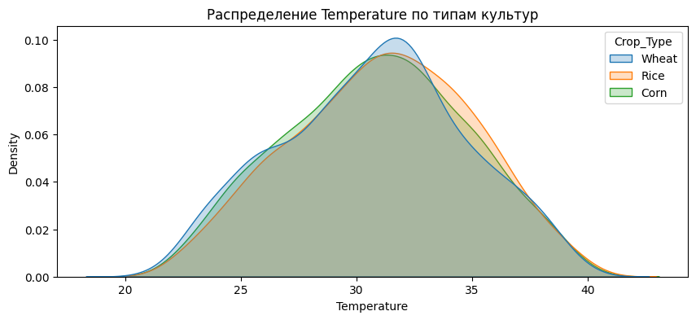

```
Результаты для признака: Rainfall
KS-статистика:
  Group1 Group2  KS_Statistic  KS_p-value                     KS_conclusion
0  Wheat   Rice      0.045009    0.312940  Нет значимых различий (p > 0.05)
1   Rice   Corn      0.038580    0.496710  Нет значимых различий (p > 0.05)
2  Wheat   Corn      0.038001    0.516882  Нет значимых различий (p > 0.05)
PSI:
  Group1 Group2       PSI                   PSI_conclusion
0  Wheat   Rice  0.023088  Изменения незначительны (< 0.1)
1  Wheat   Corn  0.014564  Изменения незначительны (< 0.1)
2   Rice   Corn  0.008687  Изменения незначительны (< 0.1)
```

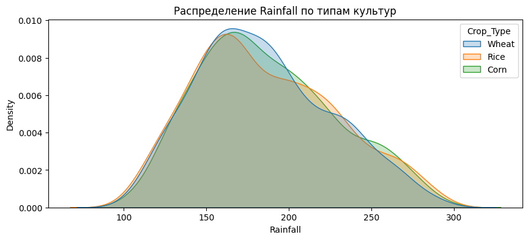

```
Результаты для признака: Soil_pH
KS-статистика:
  Group1 Group2  KS_Statistic  KS_p-value                     KS_conclusion
0  Wheat   Rice      0.047269    0.259525  Нет значимых различий (p > 0.05)
1   Rice   Corn      0.043556    0.345868  Нет значимых различий (p > 0.05)
2  Wheat   Corn      0.039144    0.478815  Нет значимых различий (p > 0.05)
PSI:
  Group1 Group2       PSI                   PSI_conclusion
0   Rice   Corn  0.024013  Изменения незначительны (< 0.1)
1  Wheat   Corn  0.010828  Изменения незначительны (< 0.1)
2  Wheat   Rice  0.005706  Изменения незначительны (< 0.1)
```

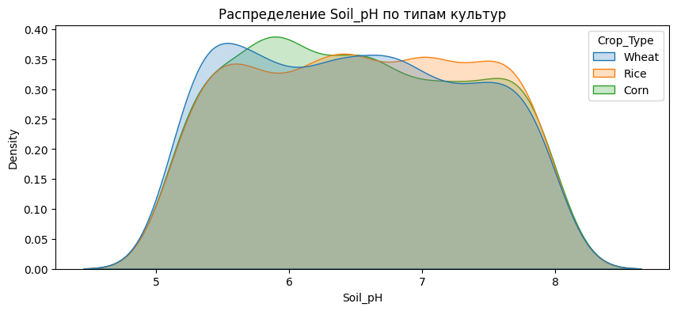

```
Результаты для признака: Fertilizer
KS-статистика:
  Group1 Group2  KS_Statistic  KS_p-value                     KS_conclusion
0  Wheat   Rice      0.041152    0.417157  Нет значимых различий (p > 0.05)
1  Wheat   Corn      0.038448    0.501815  Нет значимых различий (p > 0.05)
2   Rice   Corn      0.036281    0.575547  Нет значимых различий (p > 0.05)
PSI:
  Group1 Group2       PSI                   PSI_conclusion
0   Rice   Corn  0.023178  Изменения незначительны (< 0.1)
1  Wheat   Corn  0.012568  Изменения незначительны (< 0.1)
2  Wheat   Rice  0.005780  Изменения незначительны (< 0.1)
```

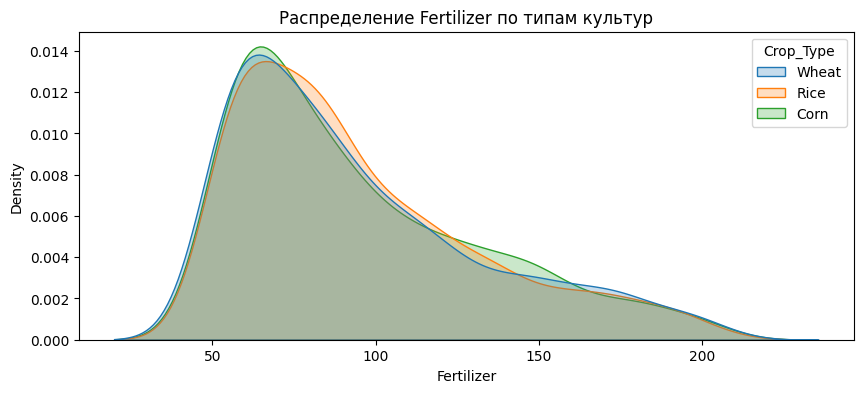

```
Результаты для признака: Nitrogen(N)
KS-статистика:
  Group1 Group2  KS_Statistic  KS_p-value                      KS_conclusion
0   Rice   Corn      0.067389    0.031388  Есть значимые различия (p < 0.05)
1  Wheat   Rice      0.064771    0.044149  Есть значимые различия (p < 0.05)
2  Wheat   Corn      0.022901    0.966072   Нет значимых различий (p > 0.05)
PSI:
  Group1 Group2       PSI                   PSI_conclusion
0  Wheat   Rice  0.030501  Изменения незначительны (< 0.1)
1   Rice   Corn  0.023543  Изменения незначительны (< 0.1)
2  Wheat   Corn  0.016256  Изменения незначительны (< 0.1)
```

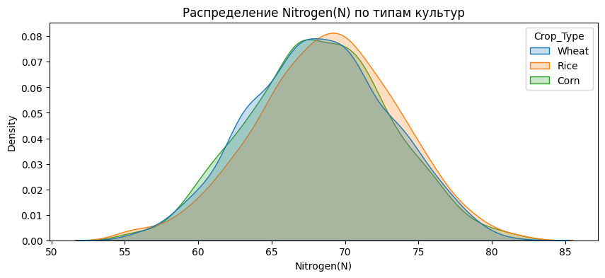

```
Результаты для признака: Phosphorus(P)
KS-статистика:
  Group1 Group2  KS_Statistic  KS_p-value                     KS_conclusion
0  Wheat   Corn      0.031115    0.759063  Нет значимых различий (p > 0.05)
1   Rice   Corn      0.029123    0.823687  Нет значимых различий (p > 0.05)
2  Wheat   Rice      0.027463    0.874499  Нет значимых различий (p > 0.05)
PSI:
  Group1 Group2       PSI                   PSI_conclusion
0   Rice   Corn  0.012193  Изменения незначительны (< 0.1)
1  Wheat   Corn  0.008953  Изменения незначительны (< 0.1)
2  Wheat   Rice  0.007104  Изменения незначительны (< 0.1)
```

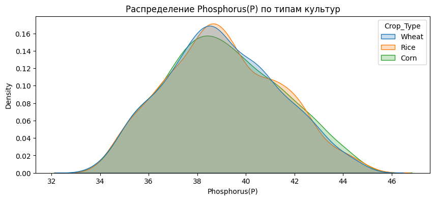

```
Результаты для признака: Potassium(K)
KS-статистика:
  Group1 Group2  KS_Statistic  KS_p-value                     KS_conclusion
0   Rice   Corn      0.046094    0.281784  Нет значимых различий (p > 0.05)
1  Wheat   Corn      0.040117    0.447583  Нет значимых различий (p > 0.05)
2  Wheat   Rice      0.032252    0.720455  Нет значимых различий (p > 0.05)
PSI:
  Group1 Group2       PSI                   PSI_conclusion
0   Rice   Corn  0.023241  Изменения незначительны (< 0.1)
1  Wheat   Rice  0.013455  Изменения незначительны (< 0.1)
2  Wheat   Corn  0.004956  Изменения незначительны (< 0.1)
```

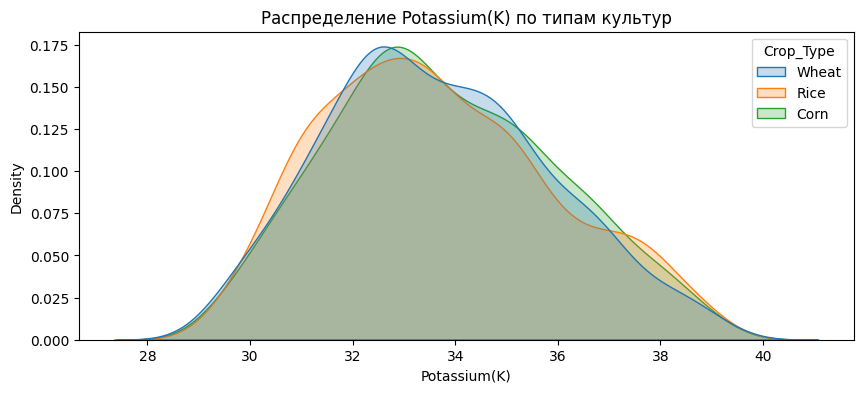

```
Результаты для признака: Yield
KS-статистика:
  Group1 Group2  KS_Statistic  KS_p-value                      KS_conclusion
0   Rice   Corn      0.115512    0.000011  Есть значимые различия (p < 0.05)
1  Wheat   Corn      0.115511    0.000011  Есть значимые различия (p < 0.05)
2  Wheat   Rice      0.024951    0.934125   Нет значимых различий (p > 0.05)
PSI:
  Group1 Group2       PSI                   PSI_conclusion
0   Rice   Corn  0.054678  Изменения незначительны (< 0.1)
1  Wheat   Corn  0.052556  Изменения незначительны (< 0.1)
2  Wheat   Rice  0.005467  Изменения незначительны (< 0.1)
```

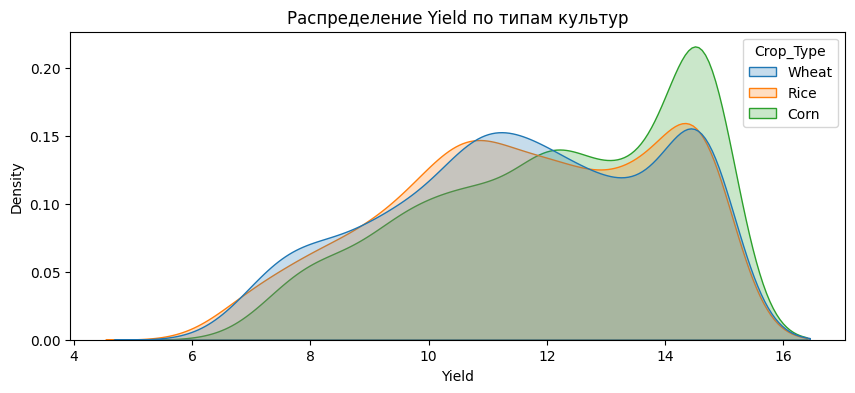

```python
# Результаты для каждого признака
for feature in features:
    print(f'Результаты для признака: {feature}')
    feature_df = results_df[results_df['Feature'] == feature]

    print(f'KS-статистика:')
    print(feature_df.sort_values('KS_Statistic', ascending=False)
          [['Group1', 'Group2', 'KS_Statistic', 'KS_p-value', 'KS_conclusion']]
          .reset_index(drop=True))

    print(f'PSI:')
    print(feature_df.sort_values('PSI', ascending=False)
          [['Group1', 'Group2', 'PSI',  'PSI_conclusion']]
          .reset_index(drop=True))

    # Визуализация распределений
    plt.figure(figsize=(10, 4))
    sns.kdeplot(data=df, x=feature, hue='Crop_Type', fill=True, common_norm=False)
    plt.title(f'Распределение {feature} по типам культур')
    plt.show()
```

**Выводы (1.1):**

1. Признаки 'Temperature', 'Rainfall', 'Soil_pH', 'Fertilizer', 'Phosphorus(P)' и 'Potassium(K)' не показывают значимых различий между группами, выборки по ним сопоставимы. Графики подтверждают отсутствие значимых различий. 'Temperature' - распределение похожее на нормальное, с небольшой отрицательной ассиметрией. 'Rainfall' - распределение похожее на нормальное, с положительной ассиметрией. 'Soil_pH' - равномерное распределение. 'Fertilizer' - распределение похожее на логнормальное. 'Phosphorus(P)' и 'Potassium(K)' - распределение похожее на нормальное.
2. Для признака 'Nitrogen(N)' наблюдаются различия между рисом и другими культурами по KS-статистике (но значения очень близки к 0.05), а результаты PSI не показывают различие распределений. Возможно, PSI менее чувствителен, так как различия не сильные. На графике видно распределение похожее на нормальное. Заметных различий на графике не видно, но тест поймал статистически значимые различия.
3. Для признака 'Yield' наблюдаются сильные отличия кукурузы от риса и пшеницы по KS-статистике, при этом PSI не показывают различие распределений (но значения стремятся к 0.1). Возможно, PSI менее чувствителен. На графике видно сильное отличие распределения кукурузы. Заметны два пика для пшеницы и риса и один выделяющийся пик для кукурузы.

**Заключение:** Наблюдаемые различия связаны с агрохимическими особенностями культур: рис чувствителен к количеству внесённого азота, а кукуруза дает более высокие урожаи.

## 1.2 Проверка гипотез касательно разницы между культурами по некоторым признакам

Сформулируем гипотезы для трёх признаков 'Fertilizer', 'Nitrogen(N)' и 'Yield':

$H_0$: Для признаков НЕТ различий между культурами.

$H_1$: Для признаков ЕСТЬ различия между культурами.

Для сравнения трх групп подойдет ANOVA, при условии соответсвия требованиям теста: нормальность, гомогенность дисперсий. На предыдущих графиках видно, что данные НЕ распределены нормально. Если проверка на нормальность (тест Шапиро-Уилка) это подтвердит, то можно использовать непараметрический критерий Крускала-Уоллиса.

```python
# Проверка нормальности
for column in ['Fertilizer', 'Nitrogen(N)', 'Yield']:
    stat, p = shapiro(df[column])
    print(f'Тест Шапиро-Уилка ({column}) p-value: {p:.4f}')

# Проверка гомогенности дисперсий
for column in ['Fertilizer', 'Nitrogen(N)', 'Yield']:
    groups = [df[df['Crop_Type'] == crop][column] for crop in ['Wheat', 'Rice', 'Corn']]
    stat, p = levene(*groups)
    print(f'Гомогенность диспресий ({column}) p-value: {p:.4f}')
```

```
Тест Шапиро-Уилка (Fertilizer) p-value: 0.0000
Тест Шапиро-Уилка (Nitrogen(N)) p-value: 0.0088
Тест Шапиро-Уилка (Yield) p-value: 0.0000
Гомогенность диспресий (Fertilizer) p-value: 0.4473
Гомогенность диспресий (Nitrogen(N)) p-value: 0.9792
Гомогенность диспресий (Yield) p-value: 0.6989
```

Для всех признаков данные НЕ распределены нормально (p-value < 0.05), гомогенность диспресий подтвердилась (p-value > 0.05). Следоватлеьно, проверку гипотез будем проводить с помощью теста Краскела-Уоллиса.

```
Результаты для признака: Fertilizer
Тест Краскела-Уоллиса p-value: 0.6746
Не отвергаем H0 — нет статистически значимых различий
Точечные оценки и 95% доверительные интервалы:
Wheat-Rice: -0.40 [-3.91, 3.11]
Wheat-Corn: -0.87 [-4.42, 2.69]
Rice-Corn: -0.47 [-3.89, 2.96]
```

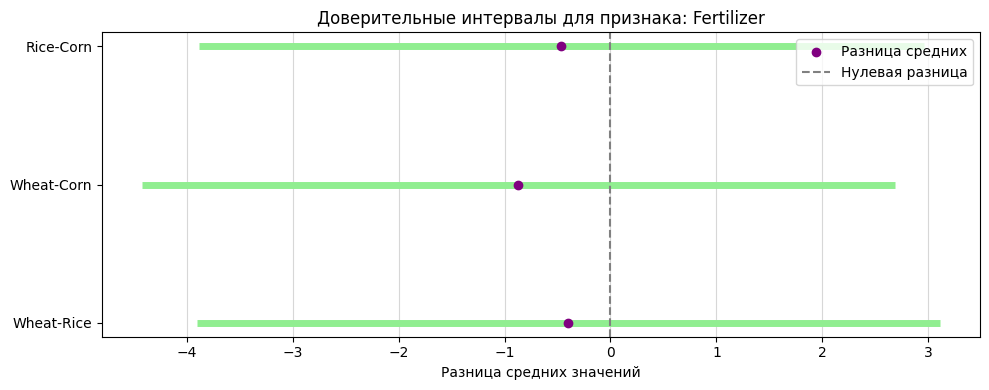

```
Результаты для признака: Nitrogen(N)
Тест Краскела-Уоллиса p-value: 0.0122
Отвергаем H0 — есть статистически значимые различия
Точечные оценки и 95% доверительные интервалы:
Wheat-Rice: -0.53 [-0.97, -0.09]
Wheat-Corn: 0.03 [-0.42, 0.47]
Rice-Corn: 0.56 [0.12, 1.01]
```

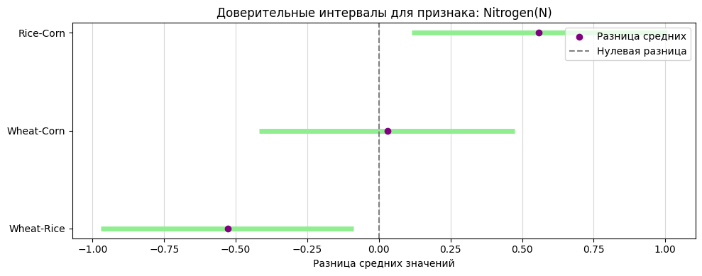

```
Результаты для признака: Yield
Тест Краскела-Уоллиса p-value: 0.0000
Отвергаем H0 — есть статистически значимые различия
Точечные оценки и 95% доверительные интервалы:
Wheat-Rice: -0.01 [-0.22, 0.20]
Wheat-Corn: -0.52 [-0.73, -0.32]
Rice-Corn: -0.51 [-0.72, -0.30]
```

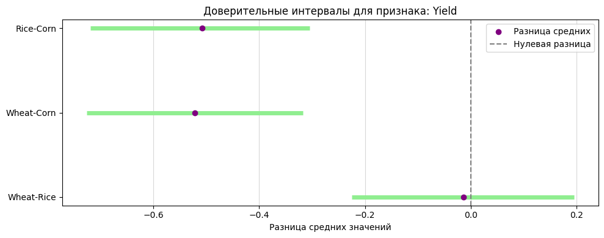

```python
variables = ['Fertilizer', 'Nitrogen(N)', 'Yield']

for variable in variables:
    print(f'Результаты для признака: {variable}')
    groups = {crop: df[df['Crop_Type'] == crop][variable] for crop in crops}

    h_stat, p_value = kruskal(*groups.values())
    print(f'Тест Краскела-Уоллиса p-value: {p_value:.4f}')
    if p_value < 0.05:
        print('Отвергаем H0 — есть статистически значимые различия')
    else:
        print('Не отвергаем H0 — нет статистически значимых различий')

    print('Точечные оценки и 95% доверительные интервалы:')
    comparison_data = []
    for i in range(len(crops)):
        for j in range(i+1, len(crops)):
            crop1, crop2 = crops[i], crops[j]
            group1, group2 = groups[crop1], groups[crop2]

            point_estimate = group1.mean() - group2.mean()

            np.random.seed(42)
            bootstrap_diffs = []
            for _ in range(10000):
                sample1 = np.random.choice(group1, size=len(group1), replace=True)
                sample2 = np.random.choice(group2, size=len(group2), replace=True)
                bootstrap_diffs.append(np.mean(sample1) - np.mean(sample2))

            ci_lower = np.percentile(bootstrap_diffs, 2.5)
            ci_upper = np.percentile(bootstrap_diffs, 97.5)

            print(f'{crop1}-{crop2}: {point_estimate:.2f} [{ci_lower:.2f}, {ci_upper:.2f}]')

            # Сохраняем данные для графика
            comparison_data.append({
                'pair': f'{crop1}-{crop2}',
                'point': point_estimate,
                'ci_lower': ci_lower,
                'ci_upper': ci_upper
            })

    # Построение графика
    plt.figure(figsize=(10, 4))
    y_positions = np.arange(len(comparison_data))

    plt.hlines(y=y_positions,
               xmin=[d['ci_lower'] for d in comparison_data],
               xmax=[d['ci_upper'] for d in comparison_data],
               color='lightgreen',
               linewidth=5)

    plt.scatter([d['point'] for d in comparison_data],
                y_positions,
                color='purple',
                zorder=3,
                label='Разница средних')

    plt.axvline(0, linestyle='--', color='gray', label='Нулевая разница')
    plt.yticks(y_positions, [d['pair'] for d in comparison_data])
    plt.xlabel('Разница средних значений')
    plt.title(f'Доверительные интервалы для признака: {variable}')
    plt.legend()
    plt.grid(axis='x', linestyle='-', alpha=0.5)
    plt.tight_layout()
    plt.show()
```

**Выводы (1.2):**

1. Для признака 'Fertilizer' тест Краскела-Уоллиса ожидаемо не обнаружил статистически значимых различий. Для каждой пары сравниваемых культур получен достаточно широкий доверительный интервал, который включает 0, что подтверждает отсутствие различий применения удобрений между культураим.
2. Для признака 'Nitrogen(N)' тест Краскела-Уоллиса обнаружил статистически значимые различия. Анализ доверительных интервалов показал присутствие различий азотного питания между рисом и другими культураим (доверительный интервал не включает 0, но находится рядом с ним). Смещение доверительных интервалов относительно 0 указывает на более высокие значения содержания азота в почве для риса, в сравнении с другими культурами. Между пшеницей и кукурузой нет значимых различий, доверительный интервал включает 0.
3. Для признака 'Yield' тест Краскела-Уоллиса обнаружил сильные статистически значимые различия (p-value = 0.0000). Анализ доверительных интервалов показал присутствие различий урожайности между кукурузой и другими культураим (доверительный интервал не включает 0). Смещение доверительных интервалов относительно 0 указывает на более высокие значения урожайности для кукурузы, в сравнении с другими культурами. Между пшеницей и рисом нет значимых различий, доверительный интервал включает 0. Для признака 'Yield' получен самый узкий доверительный интервал.

**Заключение:** Результаты проверки гипотез соотносятся с KS статистикой и PSI. Наблюдаемые различия, связаные с агрохимическими особенностями культур подтвердились.

## 1.3 Продуктовые гипотезы причин наличия различий между культурами и эксперименты для повышения показателей отстающих культур

*P.S. Тут будет немного агрохими, чтобы объяснить полученные результаты и отсутствие необходимости их корректировки.*

**Признак 'Nitrogen(N)':** повышенное содержание азота в почве для риса в сравненнии с другими культурами:

H1: Специфические условия выращивания риса: при затоплении почвы единственным источником питания риса становится аммонийный азот.

H2: Особенности роста риса и потребность в питательных веществах: азот - главная составная часть всех белков и некоторых небелковых соединений риса.

Другие культуры не нуждаются в повышении показателей азотного питания, так как полученные результаты соответсвуют установленным нормаам внесения азота.

Эксперименты для оптимизация азотного питания различных культур: A/B-тест с вариацией доз и форм азотных удобрений, который поможет научно обосновать выбор удобрений для каждой культуры, снизить затраты и экологические риски.

**Признак 'Yield':** повышенная урожайность кукурузы относительно других культур:

H1: Эффективная фотосинтетическая активность кукурузы: в 2–3 раза эффективнее, чем у других зерновых культур.

Н2: Потребление большого количества влаги. Кукуруза активно потребляет влагу, но экономно её расходует.

Полученные результаты соответсвуют агрохимическим показателям урожайности для изученных культур. Нет задачи повысить урожайность отстающих культур, необходимо повышать урожайность в соответсвии с особенностями и возможностями каждой культуры по отдельности.

Эксперименты для повышения урожайности: Использовать методы ML для подбора оптимального для заданных условий сорта культуры на основе исторических данных.

#### Изучим влияние признаков на урожайность

Для визуализации корреляции используем столбчатую диаграмму, так как между собой признаки не связаны и нам нужно показать только силу влияния каждого признака на урожайность.

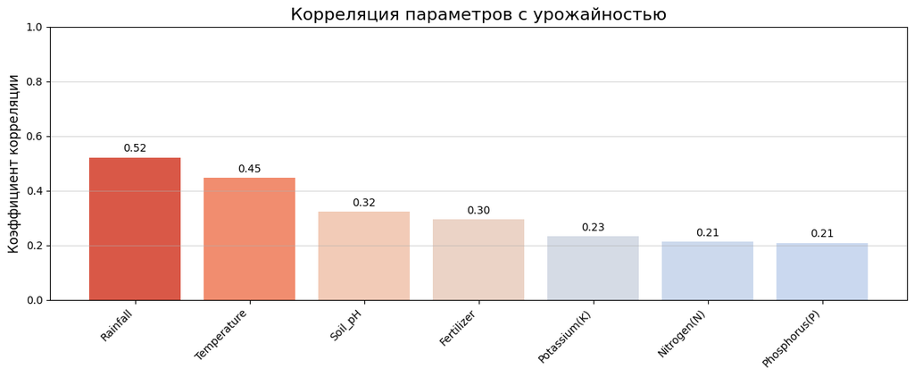

```python
corr_series = df[['Temperature', 'Rainfall', 'Soil_pH',
                 'Nitrogen(N)', 'Phosphorus(P)', 'Potassium(K)',
                 'Fertilizer', 'Yield']].corr()['Yield'].drop('Yield')
corr_sorted = corr_series.sort_values(ascending=False)


plt.figure(figsize=(12, 5))

norm = plt.Normalize(-0.09, 0.6)
colors = plt.cm.coolwarm(norm(corr_sorted.values))
bars = plt.bar(corr_sorted.index,
               corr_sorted.values,
               color=colors)

plt.title('Корреляция параметров с урожайностью', fontsize=16)
plt.ylabel('Коэффициент корреляции', fontsize=12)
plt.ylim(0, 1)
plt.axhline(0, color='black', linewidth=0.8)
plt.xticks(rotation=45, ha='right')
plt.grid(axis='y', linestyle='-', alpha=0.5)

for bar in bars:
    height = bar.get_height()
    plt.text(bar.get_x() + bar.get_width()/2.,
             height + 0.02 if height > 0 else height - 0.08,
             f'{height:.2f}',
             ha='center')

plt.tight_layout()
plt.show()
```

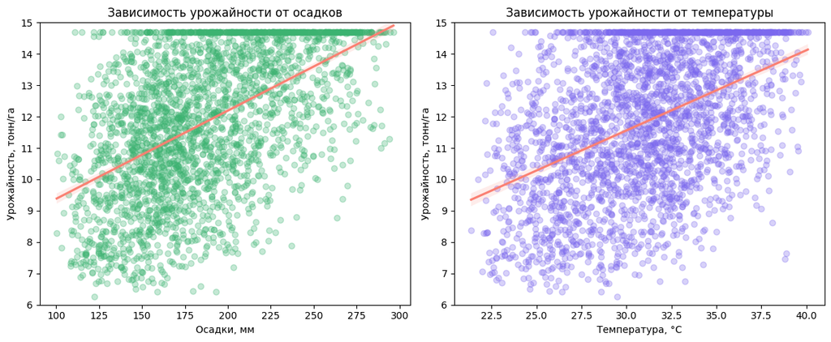

```python
fig, axes = plt.subplots(1, 2, figsize=(12, 5))

sns.regplot(
    data=df,
    x='Rainfall',
    y='Yield',
    ax=axes[0],
    scatter_kws={'color': 'mediumseagreen',
                 'alpha': 0.3},
    line_kws={'color': 'salmon'}
)
axes[0].set_title('Зависимость урожайности от осадков')
axes[0].set_xlabel('Осадки, мм')
axes[0].set_ylabel('Урожайность, тонн/га')
axes[0].set_ylim(6, 15)

sns.regplot(
    data=df,
    x='Temperature',
    y='Yield',
    ax=axes[1],
    scatter_kws={'color': 'mediumslateblue',
                 'alpha': 0.3},
    line_kws={'color': 'salmon'}
)
axes[1].set_title('Зависимость урожайности от температуры')
axes[1].set_xlabel('Температура, °C')
axes[1].set_ylabel('Урожайность, тонн/га')
axes[1].set_ylim(6, 15)

plt.tight_layout()
plt.show()
```

**Выводы (1.3):**

1. **'Rainfall'**: Самая сильная связь получена для колличества осадков.
2. **'Temperature'**: Сильная корреляция (относительно полученных результатов) подтверждает важность температурного режима для повышения урожайности.
3. **'Soil_pH' и 'Fertilizer'**: Средняя корреляция для кислотности почвы и количества удобрений показывает их менее значимое влияние на урожайность.
4. **'Nitrogen(N)', 'Phosphorus(P)', 'Potassium(K)'**: Микроэлементы по отдельности заметно меньше влияют на урожайность, чем общее количество вносимых удобрений. При этом влияние на урожайность одинаково между микроэлементами.

Построенные диаграммы рассеияния с линией регрессии показывают зависимость урожайности от количества осадков и температуры. Несмотря на сильный разброс точек можно заметить тенденцию данных к положительной корреляции.

# 2. Регрессионный анализ

1 Оценить модель линейной регрессии методом МНК, подготовить репорт модели и проинтерпретировать оценки коэффициентов.

2 Провести тесты на гетероскедастичность, мультиколлинеарность (как визуальные, так и численные), дать комментарии по произведенным тестам. В случае нарушения предпосылок Гаусса-Маркова – принять соответствующие корректирующие модель действия, после чего повторить пункт 1.

3 В ходе анализа протестируйте как минимум 2 спецификации моделей. Финальная спецификация модели может включать не все факторы и не все наблюдения из исходной выборки. Продемонстрируйте на примере финальной и одной из промежуточных моделей, по каким критериям и метрикам был произведен выбор в пользу финальной спецификации. Дайте трактовку значениям этих критериев и метрик.

#### 2.1 Оценка модели линейной регрессии методом МНК

```python
# Кодируем категориальную переменную 'Crop_Type'
df_code = pd.get_dummies(df, columns=['Crop_Type'], drop_first=True)
df_code['Crop_Type_Rice'] = df_code['Crop_Type_Rice'].astype(float)
df_code['Crop_Type_Wheat'] = df_code['Crop_Type_Wheat'].astype(float)
```

```python
# Модель 1: все переменные
X = df_code.drop('Yield', axis=1)
y = df_code['Yield']
X = sm.add_constant(X)

model_1 = sm.OLS(y, X).fit()
print(model_1.summary())
```

```
                            OLS Regression Results
==============================================================================
Dep. Variable:                  Yield   R-squared:                       0.815
Model:                            OLS   Adj. R-squared:                  0.814
Method:                 Least Squares   F-statistic:                     1314.
Date:                Sat, 15 Mar 2025   Prob (F-statistic):               0.00
Time:                        20:51:15   Log-Likelihood:                -3736.8
No. Observations:                2694   AIC:                             7494.
Df Residuals:                    2684   BIC:                             7553.
Df Model:                           9
Covariance Type:            nonrobust
===================================================================================
                      coef    std err          t      P>|t|      [0.025      0.975]
-----------------------------------------------------------------------------------
const             -30.5495      0.547    -55.881      0.000     -31.622     -29.478
Temperature         0.2470      0.005     51.867      0.000       0.238       0.256
Rainfall            0.0286      0.000     63.858      0.000       0.028       0.030
Soil_pH             0.8450      0.022     37.657      0.000       0.801       0.889
Fertilizer          0.0186      0.000     37.675      0.000       0.018       0.020
Nitrogen(N)         0.0915      0.004     23.432      0.000       0.084       0.099
Phosphorus(P)       0.2196      0.008     27.384      0.000       0.204       0.235
Potassium(K)        0.2250      0.008     26.630      0.000       0.208       0.242
Crop_Type_Rice     -0.5846      0.046    -12.755      0.000      -0.674      -0.495
Crop_Type_Wheat    -0.3495      0.046     -7.630      0.000      -0.439      -0.260
==============================================================================
Omnibus:                       12.094   Durbin-Watson:                   2.011
Prob(Omnibus):                  0.002   Jarque-Bera (JB):               12.115
Skew:                          -0.162   Prob(JB):                      0.00234
Kurtosis:                       3.049   Cond. No.                     6.75e+03
==============================================================================

Notes:
[1] Standard Errors assume that the covariance matrix of the errors is correctly specified.
[2] The condition number is large, 6.75e+03. This might indicate that there are
strong multicollinearity or other numerical problems.
```

**Выводы (2.1):**

1. **R-squared**: Модель объясняет 81.5% дисперсии зависимой переменной Yield, что говорит о хорошем соответствии модели данным. **Adj. R-squared**: скорректированный коэффицинет равен обычному, что ожидаемо при большом количестве наблюдений (2694) и маленьком числе предикторов (9).
2. **F-statistic**: Модель статистически значима (p-value=0.00), все коэффициенты имеют p-value < 0.05, что указывает на их статистическую значимость.
3. **Статистическая значимость переменных:** Все коэффициенты значимы на уровне p-value < 0.001, их доверительные интервалы не включают ноль.

Анализ переменных:

1. Temperature: Увеличение температуры на 1°C приводит к росту урожая на 0.25 единиц.
2. Rainfall: Увеличение количества осадков на 1 мм повышает урожай на 0.03 единицы.
3. Soil_pH: Увеличение pH почвы на 1 единицу увеличивает урожай на 0.85 единицы.
4. Fertilizer: Каждый дополнительный 1 кг удобрения добавляет 0.019 единицы урожая.
5. Nitrogen(N), Phosphorus(P), Potassium(K): Содержание в почве всех питательных веществ положительно влияют на урожай. Для азота коэффициент наименьший.
6. Crop_Type_Rice: Урожай риса ниже на 0.58 единиц.
7. Crop_Type_Wheat: Урожай пшеницы ниже на 0.35 единиц.

Проблемы модели:

1. **Cond. No.**: Высокое число обусловленности (> 1000) указывает на наличие мультиколлинеарности.
2. **Отрицательная константа**: При нулевых значениях всех предикторов урожай был бы отрицательны. Это связано с экстраполяцией модели за пределы разумного диапазона данных, так как переменные не центрированы. Константа не имеет практического смысла.
3. **Durbin-Watson**: Значение близко к 2, что указывает на отсутствие автокорреляции.
4. **Jarque-Bera**: Остатки не распределены нормально (p-value < 0.05).

**Заключение:** Необходимо провести проверку на мультиколлинеарность, а также преобразовать данные, для получения адекватных коэффициентов для осмысленного анализа переменных.

#### 2.2 Тесты на гетероскедастичность и мультиколлинеарность

```
Тест Бреуша-Пагана p-value: 0.0029
```

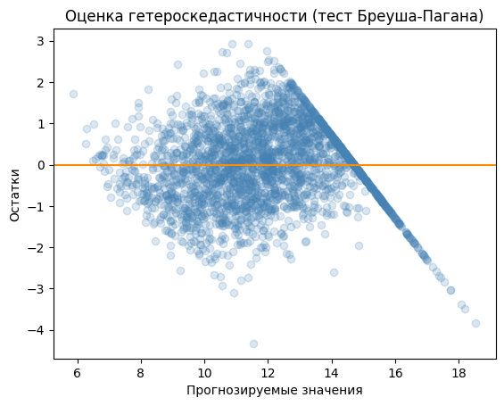

```python
# Тест Бреуша-Пагана
residuals = model_1.resid
bp_test = het_breuschpagan(residuals, X)
print(f'Тест Бреуша-Пагана p-value: {bp_test[1]:.4f}\n')

plt.scatter(model_1.fittedvalues, residuals, color='steelblue', alpha=0.2)
plt.axhline(0, color='darkorange', linestyle='-')
plt.title('Оценка гетероскедастичности (тест Бреуша-Пагана)')
plt.xlabel('Прогнозируемые значения')
plt.ylabel('Остатки')
plt.show()
```

```python
# Проверка на мультиколлинеарность через VIF
vif_data = pd.DataFrame()
vif_data["feature"] = X.columns
vif_data["VIF"] = [variance_inflation_factor(X.values, i) for i in range(len(X.columns))]
print("VIF данные:\n", vif_data)
```

```
VIF данные:
            feature         VIF
0            const  854.963335
1      Temperature    1.003933
2         Rainfall    1.003562
3          Soil_pH    1.002255
4       Fertilizer    1.001830
5      Nitrogen(N)    1.006379
6    Phosphorus(P)    1.002341
7     Potassium(K)    1.002197
8   Crop_Type_Rice    1.332853
9  Crop_Type_Wheat    1.329583
```

**Выводы (2.2):**

**Заключение:** Проверка VIF показала отсутствие мультиколлинеарности, думаю, что полученное в модели высокое число обусловленности вызвано разномасштабностью данных, например, 'Temperature' в градусах и 'Fertilizer' в килограммах.

#### 2.3 Протестируем вторую спецификацию модели

Для уменьшения числа обусловленности и улучшения интерпретации коэффициенто преобразуем все предикторы к стандартному масштабу (Z-оценка: вычитаем среднее и делим на стандартное отклонение).

```python
# Стандартизация непрерывных переменных
continuous_features = ['Temperature', 'Rainfall', 'Soil_pH', 'Fertilizer', 'Nitrogen(N)', 'Phosphorus(P)', 'Potassium(K)']
X_continuous = df_code[continuous_features]

scaler = StandardScaler()
X_scaled = scaler.fit_transform(X_continuous)
X_scaled = pd.DataFrame(X_scaled, columns=continuous_features)
```

```python
# Модель 2: стандартизированные переменные
X = pd.concat([
    X_scaled,
    df_code[['Crop_Type_Rice', 'Crop_Type_Wheat']]
], axis=1)
X = sm.add_constant(X)
y = df_code['Yield']

model_2 = sm.OLS(y, X).fit()
print(model_2.summary())
```

```
                            OLS Regression Results
==============================================================================
Dep. Variable:                  Yield   R-squared:                       0.815
Model:                            OLS   Adj. R-squared:                  0.814
Method:                 Least Squares   F-statistic:                     1314.
Date:                Sat, 15 Mar 2025   Prob (F-statistic):               0.00
Time:                        20:51:15   Log-Likelihood:                -3736.8
No. Observations:                2694   AIC:                             7494.
Df Residuals:                    2684   BIC:                             7553.
Df Model:                           9
Covariance Type:            nonrobust
===================================================================================
                      coef    std err          t      P>|t|      [0.025      0.975]
-----------------------------------------------------------------------------------
const              12.1096      0.032    375.323      0.000      12.046      12.173
Temperature         0.9716      0.019     51.867      0.000       0.935       1.008
Rainfall            1.1961      0.019     63.858      0.000       1.159       1.233
Soil_pH             0.7049      0.019     37.657      0.000       0.668       0.742
Fertilizer          0.7051      0.019     37.675      0.000       0.668       0.742
Nitrogen(N)         0.4395      0.019     23.432      0.000       0.403       0.476
Phosphorus(P)       0.5126      0.019     27.384      0.000       0.476       0.549
Potassium(K)        0.4984      0.019     26.630      0.000       0.462       0.535
Crop_Type_Rice     -0.5846      0.046    -12.755      0.000      -0.674      -0.495
Crop_Type_Wheat    -0.3495      0.046     -7.630      0.000      -0.439      -0.260
==============================================================================
Omnibus:                       12.094   Durbin-Watson:                   2.011
Prob(Omnibus):                  0.002   Jarque-Bera (JB):               12.115
Skew:                          -0.162   Prob(JB):                      0.00234
Kurtosis:                       3.049   Cond. No.                         3.72
==============================================================================

Notes:
[1] Standard Errors assume that the covariance matrix of the errors is correctly specified.
```

**Вывод (2.3):**

1. **R-squared**: Модель объясняет 81.5% дисперсии зависимой переменной Yield, что говорит о хорошем соответствии модели данным.
2. **F-statistic**: Модель статистически значима (p-value=0.00).
3. **Статистическая значимость переменных:** Все коэффициенты значимы на уровне p-value < 0.001, их доверительные интервалы не включают ноль.

Анализ переменных:

1. Температура, осадки, pH почвы и удобрения оказывают наиболее сильное положительное влияние на урожайность.
2. Содержание в почве азота (N), фосфора (P) и калия (K) также положительно влияют на урожайность, но их вклад меньше.

Диагностика модели:

1. **Cond. No.**: Низкое число обусловленности указывает на отсутствие серьезной мультиколлинеарности между переменными.
2. **Durbin-Watson**: Значение близко к 2, что указывает на отсутствие автокорреляции.
3. **Omnibus и Jarque-Bera**: p-value < 0.05 указывают на отклонение распределения остатков от нормальности.

**Заключение:** Модель полезна для прогнозирования урожайности, желательно провести дополнительную диагностику остатков.